# Trabalho ECDB - Grupo 4

José Lemos (pg49838), Paulo Seixal (pg49846), Rúben Fernandes (pg49847)

14/04/2023

# 1 *Packages*

Importação dos *packages*.

```r
library(TCGAbiolinks)
library(maftools)
library(DESeq2)
library(ggplot2)
library(summarytools)
library(scales)
library(viridis)
library(clusterProfiler)
library(org.Hs.eg.db)
library(AnnotationDbi)
library(pheatmap)
library(haven)
library(textshaping)
library(ggrepel)
library(EnhancedVolcano)
library(ComplexHeatmap)
library(RColorBrewer)
library(circlize)
library(genefilter)
```

# 2 **Explicação dos dados, sua origem e relevância**

No âmbito da Unidade Curricular Extração de Conhecimento de Dados Biológicos, inserida no 1º ano de Mestrado de Bioionformática, foi proposta a realização de um trabalho que consta a análise de um conjunto de dados usando o programa R e os packages do Bioconductor.

O objetivo deste trabalho é analisar as informações genéticas presentes no dataset e extrair conhecimentos relevantes, utilizando técnicas de visualização e análise estatística em R, onde se esperam encontrar padrões e correlações que possam ser explorados para um melhor entendimento da patologia em estudo.

Neste caso, será utilizado o repositório TCGA-HNSC. Este repositório está incluido no projeto *The Cancer Genome Atlas (TCGA) Research Network*, uma iniciativa que visa recolher, partilhar e analisar dados de *Next Generation Sequencing (NGS),* com o principal foco um maior desenvolvimento da compreensão dos mecanismos do cancro a nível molecular.

O repositório TCGA-HNSC contém informações sobre pacientes com cancro do tipo escamoso da cabeça e pescoço. Estas informações podem ser utilizadas para estudar a expressão de genes e correlacioná-la com informações clínicas relevantes. A inclusão de variáveis clínicas, como informações demográficas dos pacientes, histórico de tabagismo/alcoolismo e características relacionadas à progressão da doença, pode ajudar a identificar fatores de risco e prever resultados clínicos para pacientes com este tipo de cancro.

A importância deste conjunto de dados reside no facto de que a análise de expressão génica poder fornecer *insights* valiosos sobre os processos moleculares subjacentes ao desenvolvimento e progressão do cancro do tipo escamoso da cabeça e pescoço. Combinando essas informações com as características clínicas dos pacientes, é possível identificar fatores de risco, prever resultados clínicos, bem como identificar alvos de desenvolvimento para novas terapias.

Do repositório TCGA-HNSC foram retirados e analisados conjuntos de dados, específicos para três áreas distintas, que serão abordadas no tópico seguinte:

- **Expressão génica**
- **Mutações**
- **Metadados**

# 3 **Extração dos dados e preparação de ficheiros**

A extração dos dados do repositório TCGA-HNSC foi realizada com recurso ao package TCGABiolinks. Este package permitiu construir uma query para download de dados de expressão génica e de mutações, filtrada por tópicos como *data.category, experimental.strategy*, etc., tal como demonstrado no código apresentado de seguida.

Foi necessária uma posterior preparação dos dados através da função GDCprepare que junta todas as informações relacionadas com as amostras (por exemplo, informação clínica). Os dados dos ensaios foram aramzenados nas variáveis:

- **data_unstranded**: refere-se ao número de contagens registadas para cada gene em cada amostra
- **data_fpkm_unstrand:** refere-se ao número de contagens para cada gene após a normalização FPKM

Importante referir que as informações dos metadados foram retiradas diretamente do objeto ‘**tcga-hnsc**’, através da função *colData().*

Estes dados foram posteriormente armazenados em ficheiros .csv

## Expressão génica

```r
#project info
project_summary = getProjectSummary('TCGA-HNSC')



#build query
query_gene = GDCquery(project = 'TCGA-HNSC',
        data.category = 'Transcriptome Profiling',
        experimental.strategy = 'RNA-Seq',
        workflow.type = 'STAR - Counts',
        access = 'open')

query_results = getResults(query_gene)


#download data
GDCdownload(query_gene)


#prepare data
tcga_hnsc = GDCprepare(query_gene, summarizedExperiment = TRUE)
data_unstranded = assay(tcga_hnsc, 'unstranded')
data_fpkm_unstrand = assay(tcga_hnsc, 'fpkm_unstrand')


#create files
write.csv(data_unstranded, 'data_unstranded.csv')
write.csv(data_fpkm_unstrand, 'data_fpkm_unstrand.csv')
```

Os dados de expressão génica foram divididos em dois conjuntos distintos: **data_unstranded.csv e data_fpkm_unstrand.**

No “**data_unstranded.csv**” temos os dados de expressão génica obtidos através de RNA-seq unstranded. Estes dados representam a contagem total de fragmentos para cada gene, ainda sem qualquer tipo de normalização.

No **’data_fpkm_unstrand.csv**’ temos os dados de expressão génica, já após a normalização FPKM ( *fragments per kilobase of transcript per million*). O FPKM é importante porque permite a normalização dos níveis de expressão génica, tornando possível a comparação entre diferentes amostras ou condições. Essa normalização é necessária porque o número de leituras que se alinham a um gene pode variar dependendo do tamanho do gene, ou do tipo de sequenciamento, por exemplo.

Em ambos os casos, as colunas do dataset representam as amostras enquanto que as linhas serão os genes.

## Mutações

```r
#build query mutation data
query_mutation = GDCquery(project = 'TCGA-HNSC',
                          data.category = 'Simple Nucleotide Variation',
                          access = 'open')

query_mutation_results = getResults(query_mutation)


#download data
GDCdownload(query_mutation)


#prepare mutation data
mutation_data = GDCprepare(query_mutation, summarizedExperiment = TRUE)

#create files
write_csv(mutation_data, 'mutation_data.csv')
```

Os dados das mutações foram guardados em “mutation_data.csv”. Este dataset armazena os dados das mutações genéticas das amostras estudadas no repositório de informação do TCGA-HNSC.

Este inclui tópicos como localização do cromossoma, informação sobre os alelos do tumor, classificação de variantes, entre outros dados que serão analisados mais à frente.

O estudo de mutações acaba por enquadrar-se no objetivo do nosso trabalho pois temos a possibilidade de analisar os efeitos das mutações na expressão genética e identificar padrões de mutação com o tipo de cancro HNSC.

## Metadados

```r
#create metadata
bio_data = colData(tcga_hnsc)
bio_data = as.data.frame(bio_data)
write_csv(bio_data, 'bio_data.csv')
```

Os metadados foram armazenados no dataset “bio_data.csv”. Este possui informação clínicas sobre os pacientes de onde se originaram as amostras, bem como informaç~pes biológicas sobre a própria amostra.

Incluem-se dados como idade, estadiamento do tumor, e histórico de tratamento médico até informações clínicas como número de cigarro por dia, ou consumo de álcool.

A informação deste dataset permite aos investigadores perceber melhor o relacionamento entre as características do paciente e do tumor. Por exemplo informação sobre o tipo e estado do tumor pode ajudar a melhor perceber os diferentes níveis de expressão genética entre tecidos normais ou tumorais.

# 4 **Importação dos dados**

```r
#dataset expressão genica
gene_data = as.matrix(read.csv('data_unstranded.csv', row.names = 1))
gene_data_fpkm = as.matrix(read.csv('data_fpkm_unstrand.csv', row.names = 1))

#dataset biological data
bio_data = read.csv('bio_data.csv', row.names = 1)

#dataset mutation
mutation_data = read.csv('mutation_data.csv')
```

De maneira a evitar o download sucessivo dos datasets, decidiu-se por armazenar os dados localmente em ficheiros .csv

A importação dos ficheiro é demonstrada no segmento de código acima representado.

# 5 **Pré-processamento**

```r
#tratamento valores omissos
sum(is.na(gene_data))
```

```
## [1] 0
```

```r
sum(is.na(gene_data_fpkm))
```

```
## [1] 0
```

```r
sum(is.na(bio_data$definition))
```

```
## [1] 0
```

```r
#garantir que o barcode das amostras é o mesmo nos dados de gene_data e no bio_data
all(colnames(gene_data) %in% rownames(bio_data)) #False
```

```
## [1] FALSE
```

```r
rownames(bio_data) <- gsub("-", "\\.", rownames(bio_data)) #alterar - por .
all(colnames(gene_data) %in% rownames(bio_data)) # True
```

```
## [1] TRUE
```

```r
#retirar amostras de metastases (queremos apenas comparar tecido normal com tecido tumoral primário no DESeq2)
bio_data = bio_data[bio_data$definition != 'Metastatic',]
gene_data = gene_data[,colnames(gene_data) %in% rownames(bio_data)]
gene_data_fpkm = gene_data_fpkm[,colnames(gene_data_fpkm) %in% rownames(bio_data)]
all(colnames(gene_data) %in% rownames(bio_data)) # True
```

```
## [1] TRUE
```

```r
#confirmar a ordem dos barcodes das amostras
all(colnames(gene_data) == rownames(bio_data))
```

```
## [1] TRUE
```

O pré-processamento de dados é uma etapa fundamental para garantir resultados precisos e confiáveis. Num primeira fase optamos por verificar o número de NAs no dataset de expressão génica (gene_data e gene_data_fpkm) e nos valores do bio_data$definition, sendo estes os fatores que serão utilizados mais à frente no *design* da análise de genes diferencialmente expressos. Estes fatores irão dividir as amostras entre ‘*Primary Solid Tumor*’ e ‘*Solid Tissue Normal*’. Neste caso, não se registam NAs em ambos os casos.

Queremos também garantir que os barcodes das amostras em ambos os datasets são os mesmos. Assim sendo, foi necessária a troca dos ‘-’ por ‘.’ no nome das linhas do dataset dos metadados.

Uma vez que apenas duas amostras recolhidas pertencem a tecido metastático, achamos que este número não seria suficientemente relevante para inferir sobre a diferença de expressão génica, neste caso entre tecidos de metastático e os outros já referidos. Assim sendo, optou-se por remover as amostras correspondentes ao tecido metstático em ambos os datasets.

# 6 **Seleção e análise sumária de variáveis**

Devido à elevada quantidade de variáveis que compões os datasets, optou-se por fazer uma seleção de algumas variáveis que consideramos ser de maior relevância para o caso em estudo.

Assim sendo, optamos por selecionar e análisar brevemente sete variáveis distintas: tipo de tecido, local do tumor, sexo do paciente, idade do paciente, tabaco, consumo de álcool e estadiamento do tumor.

```r
definition = bio_data$definition #tipo de tecido
stage = bio_data$ajcc_clinical_stage #estadiamento
tissue = bio_data$tissue_or_organ_of_origin #local do tumor
alcohol = bio_data$alcohol_history #consumo de alcool
smoke = bio_data$pack_years_smoked #tabagismo (packs_per_year)
smoke_disc = ifelse(is.na(smoke), "No", ifelse(smoke > 0, "Yes", "No"))
sum(is.na(smoke)) == sum(smoke_disc=='No') #tabagismo (discretização)
```

```
## [1] TRUE
```

```r
gender = bio_data$gender #sexo
age = bio_data$age_at_index #idade
```

## Tipo de tecido

Nesta variável do dataset bio_data temos informação sobre a presença ou ausência de tecido tumoral nas amostras, representado pelos valores “*Primary solid Tumor*” e “*Solid Tissue Normal*”, respetivamente.

A sua utilidade para o nosso objetivo reflete-se na possibilidade de comparar a expressão genética nos tecidos normais e tumorais e identificar genes diferencialmente expressos.

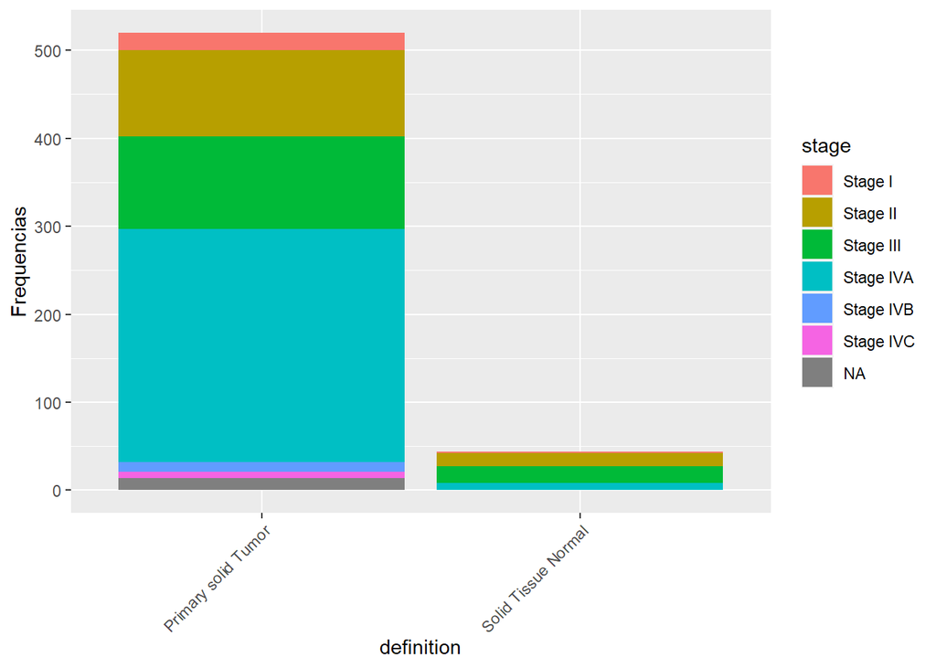

```r
#tipo de tecido
ggplot(as.data.frame(definition), aes(x = definition, fill = stage)) +
  geom_bar() +
  theme(axis.text.x = element_text(angle = 45, hjust = 1)) +
  ylab('Frequencias')
```

```r
print(dfSummary(definition, headings = FALSE), style = 'grid', dfSummary.silent  = TRUE, method = 'render')
```

**No**

**Variable**

**Stats / Values**

**Freqs (% of Valid)**

**Graph**

**Valid**

**Missing**

1

definition [character]

| 1. Primary solid Tumor |
| --- |
| 2. Solid Tissue Normal |

| 520 | ( | 92.2% | ) |
| --- | --- | --- | --- |
| 44 | ( | 7.8% | ) |

564 (100.0%)

0 (0.0%)

Generated by summarytools 1.0.1 ([R](https://www.r-project.org/) version 4.2.1)  
2023-04-17

Numa breve análise através da função dfSummary() conseguiu-se observar que a esmagadora maioria das amostras observadas são relativas ao ‘Primary Solid Tumor’ (92,2%). No gráfico é possível ainda observar uma distribuição prevalente do estadiamento IV A, comparativamente aos restantes.

A presença de estadiamento na coluna dos tecidos normais poderá não fazer sentido, no entanto, é importante referir que estas amostras de tecido normal, provêm de pacientes já diagnosticados com este tipo de cancro. Logo, embora seja um tecido saudável, as informações clínicas nos metadados irão fazer referência ao diagnóstico do paciente e respetivo estadiamento.

## Local do tumor

Esta variável armazena informação sobre o tecido ou orgão em que o tumor se desenvolveu. Ao considerar esta varíavel é possível obter um melhor contexto em relação às células e aos seus comportamentos característicos em cada orgão, bem como analisar como é afetada a progressão do tumor.

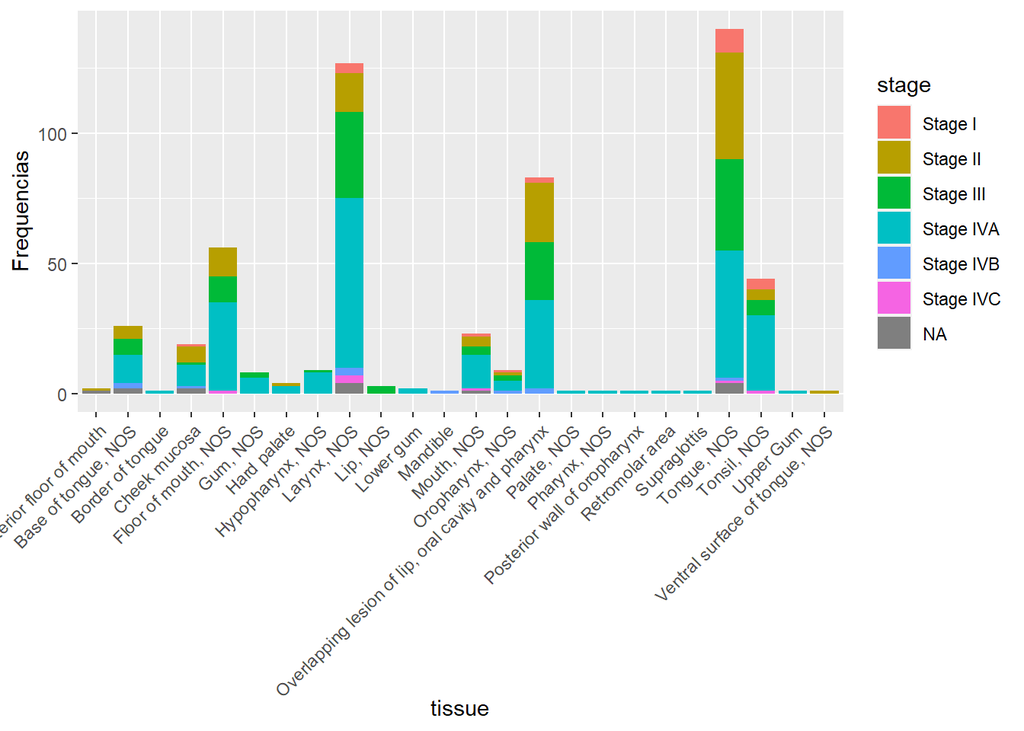

```r
#Local do tumor
ggplot(as.data.frame(tissue), aes(x = tissue, fill = stage)) +
  geom_bar() +
  theme(axis.text.x = element_text(angle = 45, hjust = 1)) +
  ylab('Frequencias')
```

```r
print(dfSummary(tissue, headings = FALSE), style = 'grid', dfSummary.silent  = TRUE, method = 'render')
```

**No**

**Variable**

**Stats / Values**

**Freqs (% of Valid)**

**Graph**

**Valid**

**Missing**

1

tissue [character]

| 1. Tongue, NOS |
| --- |
| 2. Larynx, NOS |
| 3. Overlapping lesion of lip |
| 4. Floor of mouth, NOS |
| 5. Tonsil, NOS |
| 6. Base of tongue, NOS |
| 7. Mouth, NOS |
| 8. Cheek mucosa |
| 9. Hypopharynx, NOS |
| 10. Oropharynx, NOS |
| [ 14 others ] |

| 140 | ( | 24.8% | ) |
| --- | --- | --- | --- |
| 127 | ( | 22.5% | ) |
| 83 | ( | 14.7% | ) |
| 56 | ( | 9.9% | ) |
| 44 | ( | 7.8% | ) |
| 26 | ( | 4.6% | ) |
| 23 | ( | 4.1% | ) |
| 19 | ( | 3.4% | ) |
| 9 | ( | 1.6% | ) |
| 9 | ( | 1.6% | ) |
| 28 | ( | 5.0% | ) |

564 (100.0%)

0 (0.0%)

Generated by summarytools 1.0.1 ([R](https://www.r-project.org/) version 4.2.1)  
2023-04-17

Mais uma vez, regista-se uma maior prevalência de casos em estadiamento IV A, como é possível ser verificado no gráfico apresentado.

## Sexo

Esta variável armazena informações sobre o sexo do paciente. A partir destes dados podemos inferir relativamente à prevalência de casos quanto ao sexo do paciente no presente estudo.

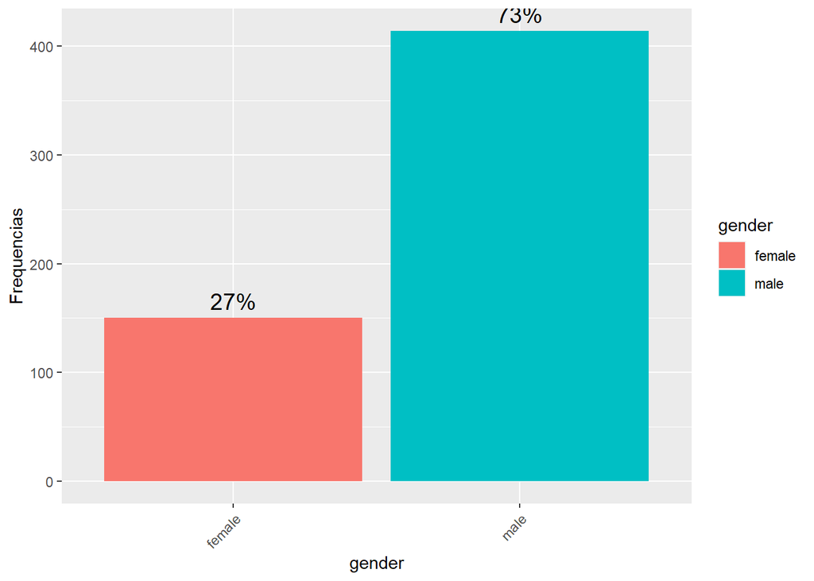

```r
#Sexo
ggplot(as.data.frame(gender), aes(x = gender, fill = gender)) +
  geom_bar() +
  geom_text(aes(label = paste0(round((..count..)/sum(..count..) * 100), "%")),
            stat = "count", vjust = -0.5, size = 5) +
  theme(axis.text.x = element_text(angle = 45, hjust = 1)) +
  ylab('Frequencias')
```

```r
print(dfSummary(gender, headings = FALSE), style = 'grid', dfSummary.silent  = TRUE, method = 'render')
```

**No**

**Variable**

**Stats / Values**

**Freqs (% of Valid)**

**Graph**

**Valid**

**Missing**

1

gender [character]

| 1. female |
| --- |
| 2. male |

| 150 | ( | 26.6% | ) |
| --- | --- | --- | --- |
| 414 | ( | 73.4% | ) |

564 (100.0%)

0 (0.0%)

Generated by summarytools 1.0.1 ([R](https://www.r-project.org/) version 4.2.1)  
2023-04-17

## Idade

Esta varriável representa a idade com que os pacientes foram diagnosticados com cancro. Com estes dados podemos identificar padrões de como este tipo de cancro possa estar associado a grupos etários específicos.

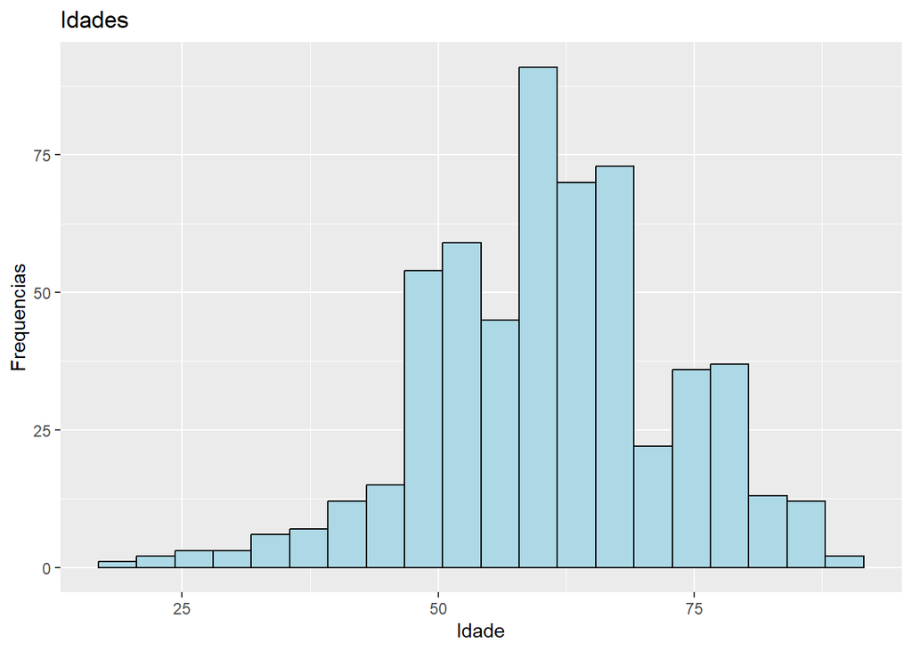

```r
#idade
ggplot(as.data.frame(age), aes(x = age)) +
  geom_histogram(bins = 20, fill = 'lightblue', color = 'black') +
  labs(title = 'Idades', x = 'Idade', y = 'Frequencias')
```

```r
print(dfSummary(age, headings = FALSE), style = 'grid', dfSummary.silent  = TRUE, method = 'render')
```

**No**

**Variable**

**Stats / Values**

**Freqs (% of Valid)**

**Graph**

**Valid**

**Missing**

1

age [integer]

| Mean (sd) : 61 (12) |
| --- |
| min ≤ med ≤ max: |
| 19 ≤ 61 ≤ 90 |
| IQR (CV) : 15.5 (0.2) |

60 distinct values

563 (99.8%)

1 (0.2%)

Generated by summarytools 1.0.1 ([R](https://www.r-project.org/) version 4.2.1)  
2023-04-17

E de esperar que a idade do diagnóstico seja tendencialmente mais avançada devido ao cariz mutacional da doença. Ou seja, a maior probabilidade de mutações espontâneas, bem como a acumulação de exposição a agentes externos carcinogénicos, leva-nos a associar grande parte dos tipos de cancro a idades mais avançadas.

Este facto é corroborado pelos resultados apresentados, onde se regista uma média de 61 anos de idade no diagnóstico, sendo que a esmagadora maioria dos pacientes apresenta idade superiores a aproximadamente 50 anos.

## Tabaco

Esta variável representa os hábitos tabágicos dos pacientes. Com estes dados podemos tentar identificar padrões de associação de exposição ao tabaco com o desenvolvimento do cancro.

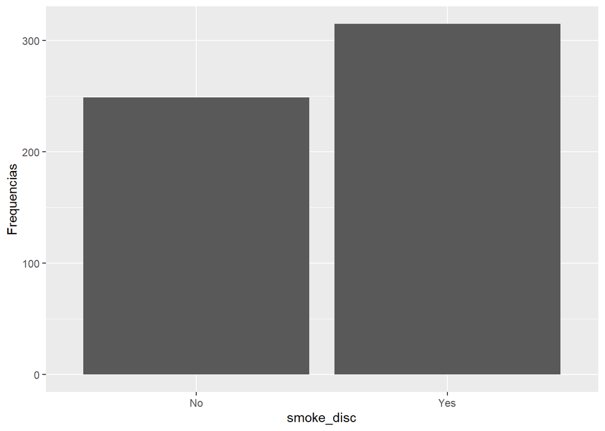

```r
#tabaco
ggplot(as.data.frame(smoke_disc), aes(x = smoke_disc)) +
  geom_bar() +
  ylab('Frequencias')
```

```r
print(dfSummary(smoke, headings = FALSE), style = 'grid', dfSummary.silent  = TRUE, method = 'render')
```

**No**

**Variable**

**Stats / Values**

**Freqs (% of Valid)**

**Graph**

**Valid**

**Missing**

1

smoke [numeric]

| Mean (sd) : 46 (34.7) |
| --- |
| min ≤ med ≤ max: |
| 0 ≤ 40 ≤ 300 |
| IQR (CV) : 35 (0.8) |

87 distinct values

315 (55.9%)

249 (44.1%)

Generated by summarytools 1.0.1 ([R](https://www.r-project.org/) version 4.2.1)  
2023-04-17

Visto que se trata de um tumor na zona da cabeça e pescoço, este fator apresenta-se com grande relevância para o estudo. Desta forma foi feita uma categorização entre fumador e não fumador, onde se assumiu os NAs como sendo não fumadores.

Relativamente aos resultados obtidos, em dfSummary podemos observar que os fumadores fumam uma média de 46 maços por ano.

No entanto, as amostras entre os fumadores e os não-fumadores apresentam-se bastante equilibradas, com 55,9% para os fumadores e 44,1% para os não fumadores.

## Álcool

Esta variável representa consumo de álcool dos pacientes. Com estes dados podemos tentar identificar padrões de associação de consumo de álcool com o desenvolvimento do cancro.

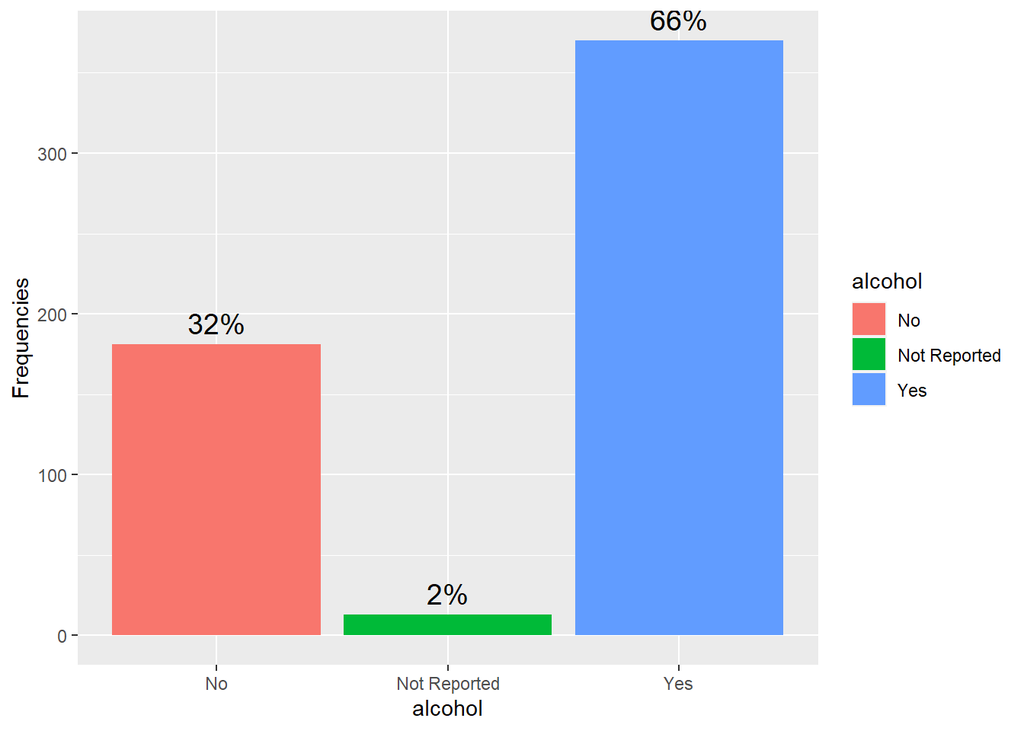

```r
#alcool
ggplot(as.data.frame(alcohol), aes(x = alcohol, fill = alcohol)) +
  geom_bar() +
  geom_text(aes(label = paste0(round((..count..)/sum(..count..) * 100), "%")),
            stat = "count", vjust = -0.5, size = 5) +
  ylab('Frequencies')
```

```r
print(dfSummary(alcohol, headings = FALSE), style = 'grid', dfSummary.silent  = TRUE, method = 'render')
```

**No**

**Variable**

**Stats / Values**

**Freqs (% of Valid)**

**Graph**

**Valid**

**Missing**

1

alcohol [character]

| 1. No |
| --- |
| 2. Not Reported |
| 3. Yes |

| 181 | ( | 32.1% | ) |
| --- | --- | --- | --- |
| 13 | ( | 2.3% | ) |
| 370 | ( | 65.6% | ) |

564 (100.0%)

0 (0.0%)

Generated by summarytools 1.0.1 ([R](https://www.r-project.org/) version 4.2.1)  
2023-04-17

Face aos resultados obtidos, observa-se que 66% dos pacientes eram consumidores de álcool. No entanto, as informações clínicas no paciente não faziam menção à frequência do consumo.

Assim sendo, embora estes resultados possam levar a uma conclusão de que o consumo de álcool possa ser identificado como um fator de risco para o desenvolvimento deste tipo de cancro, a escassez de informação também deve ser tida em conta.

Informações quanto à frequência do consumo, devem também ser registadas.

## Estadiamento

A variável ajcc_clinical_stage representa a extensão da progressão do tumor na respetiva amostra com valores que são denominados de forma crescente como “Stage I”, “Stage II”, “Stage III”, “Stage IVA”, “Stage IVB”. Com esta informação as amostras poderam ser agrupadas por grupos e analisadas no que toca aos padrões de expressão genética de cada grupo, comparando-os.

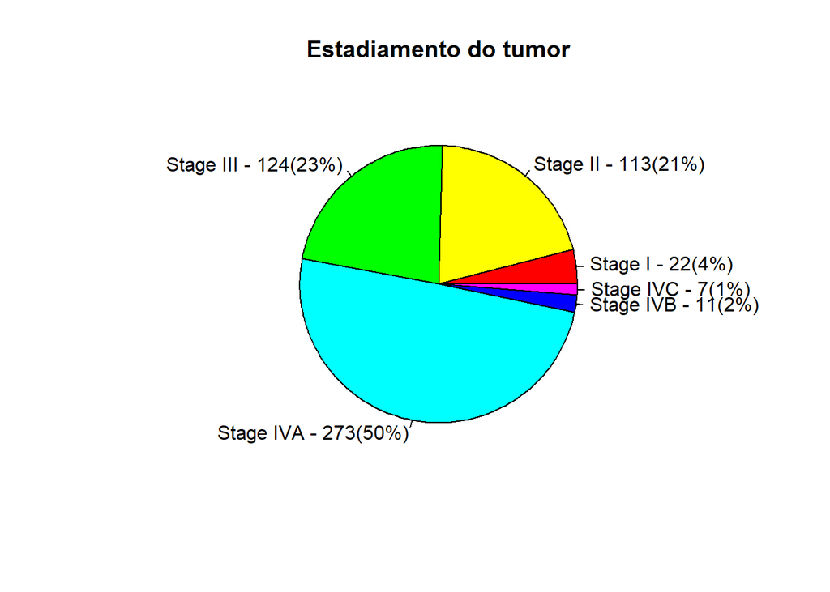

```r
s = as.data.frame(stage)
stage_freq = table(s$stage)
df = data.frame(stage = stage(stage_freq), freq = as.numeric(stage_freq))

slices = df$freq
names = df$stage.Var1
pct = round(slices/sum(slices)*100)

new_labels = paste(names, ' - ', slices, '(', pct, '%',')', sep="")

pie(slices, labels = new_labels, main = "Estadiamento do tumor", col = rainbow(6))
```

```r
print(dfSummary(stage, headings = FALSE), style = 'grid', dfSummary.silent  = TRUE, method = 'render')
```

**No**

**Variable**

**Stats / Values**

**Freqs (% of Valid)**

**Graph**

**Valid**

**Missing**

1

stage [character]

| 1. Stage I |
| --- |
| 2. Stage II |
| 3. Stage III |
| 4. Stage IVA |
| 5. Stage IVB |
| 6. Stage IVC |

| 22 | ( | 4.0% | ) |
| --- | --- | --- | --- |
| 113 | ( | 20.5% | ) |
| 124 | ( | 22.5% | ) |
| 273 | ( | 49.6% | ) |
| 11 | ( | 2.0% | ) |
| 7 | ( | 1.3% | ) |

550 (97.5%)

14 (2.5%)

Generated by summarytools 1.0.1 ([R](https://www.r-project.org/) version 4.2.1)  
2023-04-17

Face aos resultados obtidos, verificamops que o estadiamento com maior prevalência nas amostras é o *Stage IVA.*

O estadiamento IV A caracteriza-se clinicamente pela presença de metsastases em orgãos adjacentes ao local original, bem como vários nódulos linfáticos próximos

# 7 **Mutações**

Através do package *maftools,* foi realizado um breve estudo de mutações. O seu estudo é importante porque fornece uma maneira eficaz de analisar e visualizar dados complexos de mutação, permitindo identificar padrões e relações importantes, bem como encontrar possíveis novos alvos terapêuticos.

```r
maftools_input = read.maf(mutation_data)
```

```
## -Validating
## -Silent variants: 23620
## -Summarizing
## --Possible FLAGS among top ten genes:
##   TTN
##   MUC16
##   SYNE1
## -Processing clinical data
## --Missing clinical data
## -Finished in 3.340s elapsed (1.860s cpu)
```

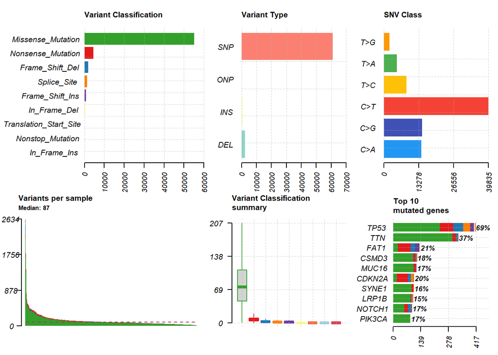

```r
plotmafSummary(maf = maftools_input,
               addStat = 'median',
               dashboard = TRUE)
```

Numa breve análise dos gráficos acima podemos concluir que a esmagadora maioria das mutações encontradas nas amostras analisadas são mutações missense. Este é um tipo de mutações pontuais no qual uma única alteração de um nucleótido resulta na codificação de um aminoácido diferente. É também possível observar que o tipo de mutação predominante é o *single nucleotide polymorphism (SNP)* onde é mais comum ocorrer a substituição de uma Citosina pela Timina. Neste estudo verifica-se também o top 10 de genes com maior associação a mutações, sendo que os genes mais afetados são o TP53 e o TTN.

Ambos os genes TP53 e TTN são frequentemente associados a patologias tumorais. O TP53 codifica uma proteina responsável pela regulação da divisão celular, atuando como supressor tumoral. O TTN codifica uma proteina que pareticipa na contração muscular, também regularmente associada a tumores do tipo escamoso, como é o caso do HNSC.

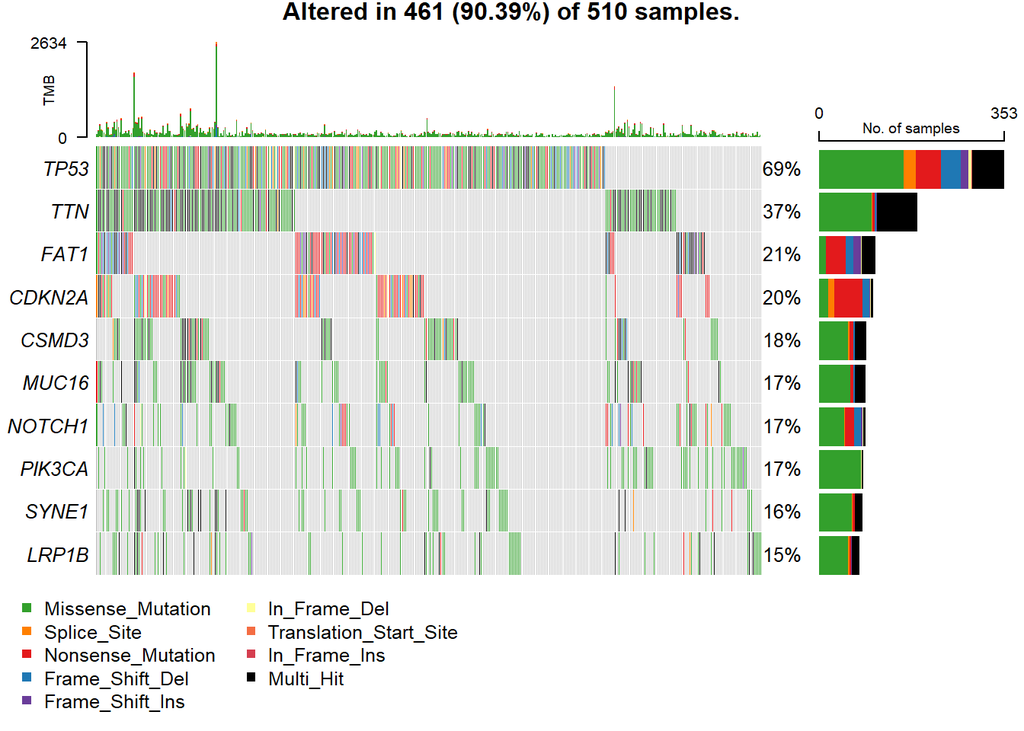

```r
oncoplot(maf = maftools_input,
         top = 10,
         removeNonMutated = TRUE)
```

No gráfico acima, é possível de se obvservar a existência de alguns picos onde se verifica em um caso a existência de 2634 de TMB (*Total number of mutations found in the DNA of cancer cells*). Aqui dá para se ter uma visão abrangente da presença de mutações por paciente, bem como o tipo de mutação.

# 8 **Filtragem do dataset através de análise univariada**

```r
#realizar t-test e verificar p-values e reirar os genes com maior evidência de expressão diferencial
tt = rowttests(gene_data_fpkm, as.factor(bio_data$definition))
rank = order(tt$p.value)
p10000 = rank[1:10000]
rows = which(tt$p.value %in% tt$p.value[p10000])
#genes com menor p-value, logo com maior probabilidade de serem diferencialmente expressos

#filtrar dataset de contagens v«elos valores anteriores
gene_data = gene_data[rownames(gene_data) %in% rownames(tt)[rows],]
dim(gene_data) #passa a contar apenas com os 10000 genes de menor p-value
```

```
## [1] 10000   564
```

Antes da análise de expressão diferencial propriamente dita, optou-se por fazer uma filtragem do dataset inicial, de forma a que o mesmo seja composto pelos genes com maior probabilidade de serem diferencialmente expressos.

Assim sendo, foi aplicada a função *rowttests()* que aplica o t-test no dataset, dividindo em dois grupos (tecido normal e tecido tumoral)

Após se efetuar o t-test a cada gene, ordenou-se os 10 000 genes com menor p-value, numa lista que será usada para filtrar o dataset gene_data, de forma a que este passe a ter apenas os 10 000 genes.

É importante referir que para aplicar o *rowttests(*) foi necessário usar o dataset **gene_data_fpkm**, pois este já apresenta valores normalizados, permitindo assim uma comparação mais fiável entre as amostras.

# 9 **Análise da expressão diferencial**

Na análise da expressão diferencial de genes o objetivo é observar se existe uma alteração estatisticamente significativa na expressão de genes entre duas condições experimentais.

Uma vez que o package **DEseq2** requer o uso de contagens não normalizadas do fragmentos, utilizou-se o *gene_data* construído no ponto anterior, e os metadados referentes em **bio_data** (neste caso a coluna *definition* para o *design*).

```r
dds = DESeqDataSetFromMatrix(countData = gene_data,
                             colData = bio_data,
                             design = ~ definition)


#filter counts under 20
keep = rowSums(counts(dds)) >= 20
dds = dds[keep,]


#set reference level
bio_data$definition = relevel(as.factor(bio_data$definition), ref = 'Solid Tissue Normal')


#run DESeq
dds = DESeq(dds)
```

Embora não seja necessário pré-filtrar genes de baixa contagem antes de executar as funções *DESeq2*, existem duas razões que tornam esta filtragem útil: ao remover linhas em que há muito poucas leituras, reduzimos o tamanho da memória do objeto de dados e aumentamos a velocidade das funções dentro do DESeq2. Esta filtragem pode também melhorar visualizações, já que recursos sem informações para expressão diferencial não serão incluidos nos gráficos.

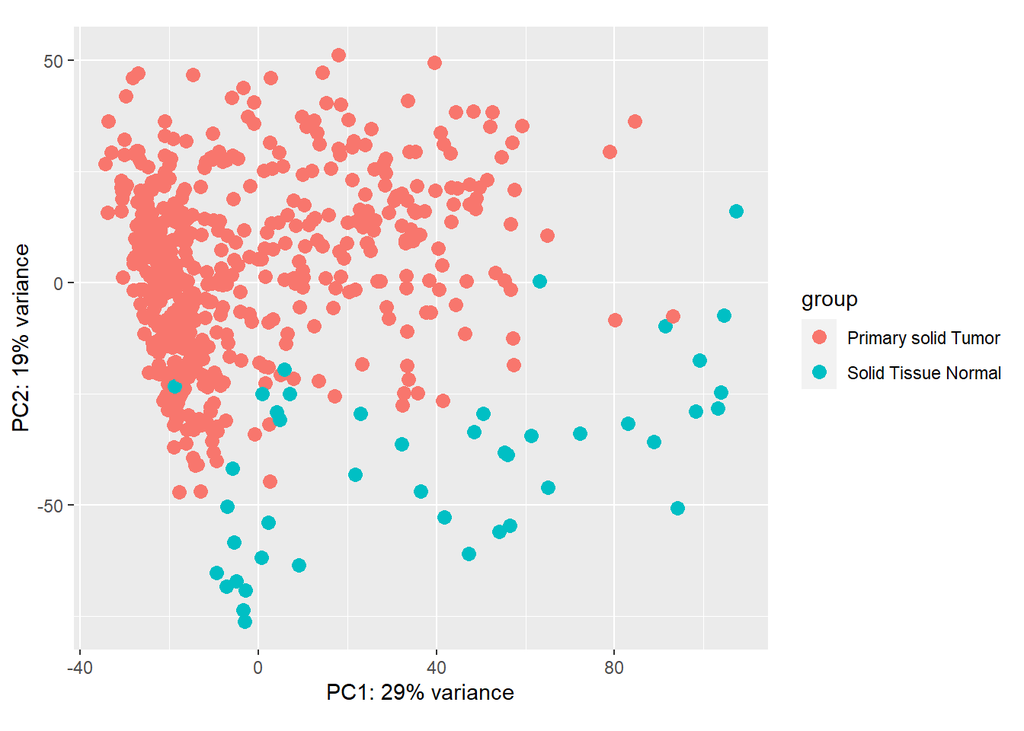

```r
#Quality control - idealmente condições semelhantes no mesmo cluster
vsdata = vst(dds, blind = FALSE)
plotPCA(vsdata, intgroup = 'definition')
```

Embora este gráfico não nos permita tirar conclusões definitivas quanto aos genes diferencialemente expressos, pode funcionar como um controlo de qualidade. Uma dispersão de genes por todo o gráfico, sem grupos claramente deinidos, pode significar um erro no processo experimental.

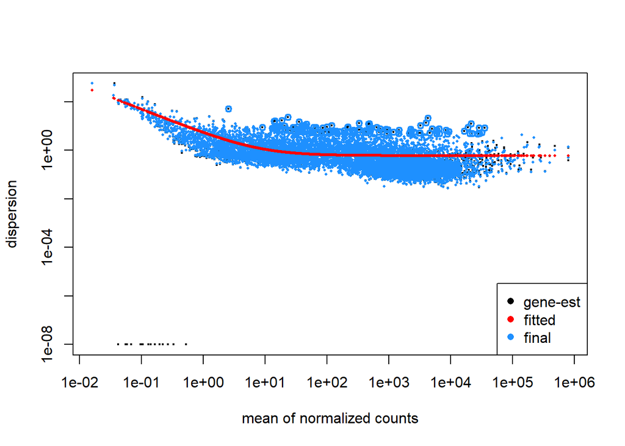

```r
#dispersion plot
plotDispEsts(dds)
```

No gráfico de dispersão acima, é esperado que os dados se disponham em torno da curva, com a dispersão diminuindo com o aumento dos níveis médios de expressão.

No entanto, e embora não seja um caso extremo, os dados observados não apresentam uma diminuição da dispersão desejável ao longo do gráfico, com a mesma a estagnar nos valores próximos de 1.

```r
#get results from DESeq
res = results(dds, alpha = 0.05)
summary(res)
```

```
##
## out of 9982 with nonzero total read count
## adjusted p-value < 0.05
## LFC > 0 (up)       : 3800, 38%
## LFC < 0 (down)     : 3919, 39%
## outliers [1]       : 0, 0%
## low counts [2]     : 0, 0%
## (mean count < 0)
## [1] see 'cooksCutoff' argument of ?results
## [2] see 'independentFiltering' argument of ?results
```

```r
#signifiatives - only padj under 0.05
sigs = na.omit(res)
sigs = sigs[sigs$padj < 0.05,]

#explore results
summary(sigs)
```

```
##
## out of 7719 with nonzero total read count
## adjusted p-value < 0.05
## LFC > 0 (up)       : 3800, 49%
## LFC < 0 (down)     : 3919, 51%
## outliers [1]       : 0, 0%
## low counts [2]     : 0, 0%
## (mean count < 0)
## [1] see 'cooksCutoff' argument of ?results
## [2] see 'independentFiltering' argument of ?results
```

Os resultados obtidos no DESeq (variavel **res)** foram depois filtrados para uma nova variável (variável **sigs**) de forma a que sejam apresentados apenas os genes mais significativos, com um *p.adjusted* inferior a 0.05.

Neste caso, foi possível encontrar 3800 genes sobre-regulados (com log2 fold change superior a 0) e 3919 genes sub-regulados (com log2 fold change inferior a 0), que serão estudados de seguida.

## 9.1 Volcano plot

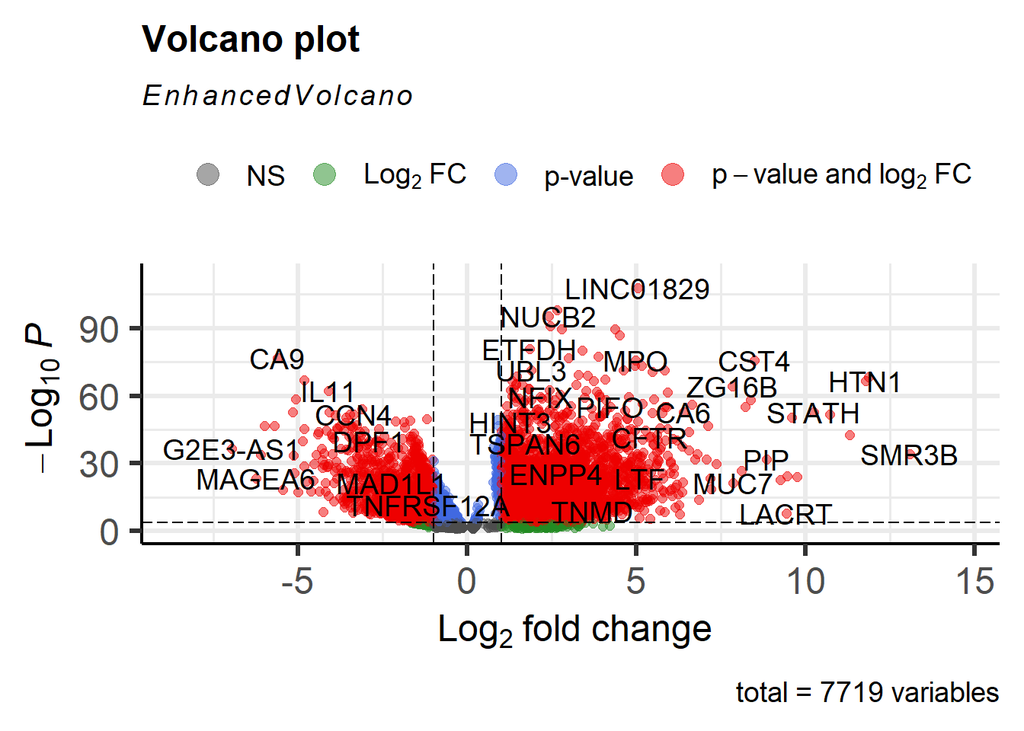

```r
#volcano plot
sigs.df = as.data.frame(sigs)
rownames(sigs.df) = gsub("\\..*","",rownames(sigs.df))
sigs.df$symbol = mapIds(org.Hs.eg.db, keys = rownames(sigs.df), keytype = 'ENSEMBL', column = 'SYMBOL')
#changed ensembl to symbol genes

EnhancedVolcano(sigs.df, x= 'log2FoldChange', y = 'padj', lab = sigs.df$symbol, pCutoff = 1e-4, FCcutoff = 1) #plot
```

Através da análise do volcano plot acima representado, podemos identificar alguns dos genes diferencialmente expressos nos tecidos normais e tumorais.

Os genes dos quadrantes superior direito como HTN1, SMR3B ou CST4, representam genes sobre-regulados, enquanto que genes no quadrante superior esquerdo como CA9, IL11 ou G2E3-AS1 representam genes que são sub-regulados

Os genes nos quadrantes inferiores não são diferencialmente expressos significativamente.

# 10 **Análise de enriquecimento**

A partir da análise de enriquecimento podemos retirar informações sobre os processos biológicos subjacentes que são afetados pelas mudanças na expressão génica e ajudar a identificar possíveis alvos terapêuticos.

```r
#sobre-expressos
genes_up = rownames(sigs)[sigs$log2FoldChange > 2]
genes_up = gsub("\\..*","",genes_up) #retirar números à frente do ponto, no código ensembl

GO_results = enrichGO(gene = genes_up, OrgDb = 'org.Hs.eg.db', keyType = 'ENSEMBL', ont = 'BP')


#sub-expressos
genes_down = rownames(sigs)[sigs$log2FoldChange < -2]
genes_down = gsub("\\..*","",genes_down)

GO_results2 = enrichGO(gene = genes_down, OrgDb = 'org.Hs.eg.db', keyType = 'ENSEMBL', ont = 'BP')
```

Na análise de enriquecimento, optou-se por selecionar e agrupar os ids ensembl dos genes, por grupos de sobre-expressos e sub-expressos. Foram selecionados os genes com um log2 fold change superior a 2 (para os sobre-expressos) e inferior a -2 (para os sub-expressos).

A partir destes ids, com a função *enrichGO,* é possível pesquisar e associar estes grupos de genes aos respetivos processos biológicos.

## Sobre-expressos

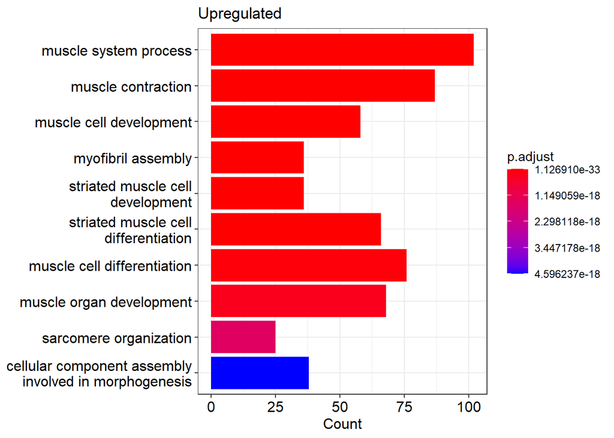

```r
barplot(GO_results, showCategory = 10, title = 'Upregulated')
```

Nos genes sobre-expressos notamos uma clara incidência sobre processos biológicos relativos ao desenvolvimento e processos musculares.

## Sub-expressos

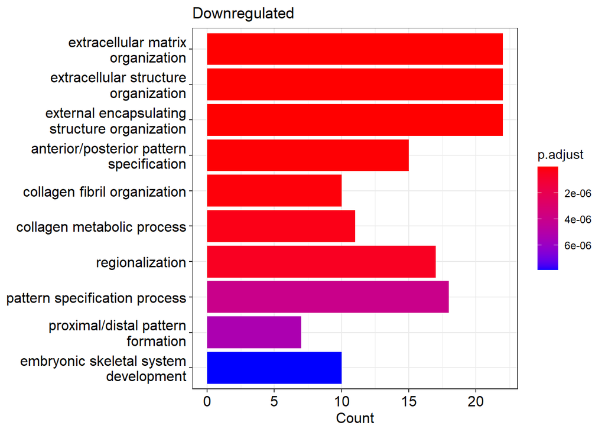

```r
barplot(GO_results2, showCategory = 10, title = 'Downregulated')
```

Nos genes sub-expressos, notamos uma incidência em genes que participam em funções de organização de estrutura celular e tecidular, bem como em mecanismos de diferenciação celular.